# TRUS IP Annual Mvmt Summary

David Wolfson

2023-01-03

These are the 7 questions I shared with the project collaborators at the last meeting in Feb 2022.

Research questions:  
1. How far are swans moving from summer territories during the non-breeding period?  
2. How long are swans spending overwintering in non-breeding areas?  
3. What are the dates that swans leave their summer territory in the fall and return in the spring?  
4. How does breeding status affect migration patterns?  
5. How do migration patterns differ by latitude?  
6. How does water condition influence swan settlement during the non-breeding period?  
7. What is the degree of annual within-individual variability and within-population variability in migration patterns?

Here is the list of migration metrics that I have for all the models fit with mcp:

1. **Fall migration onset (for long-distance migrants)**
   - migration extent >100km
   - transition must be between July and December
   - transition between segments >2 km
   - movement must be away from origin
2. **First departure from summer territory (applies to residents and short-distance movements)**
   - no distance threshold
   - no seasonal date range requirement
   - transition between segments >2 km
   - movement must be away from origin
3. **Number of stops (segments additional to first and last, so a ‘traditional’ migrant with no staging would have 1)**
   - transitions between segments >2 km
   - time between segments >2 days
4. **Duration of each stop**
   - transitions between segments >2 km
   - time between segments >2 days
5. **Overall extent of migration (distance between max and min displacement segments)**
   - transitions between segments >2 km
6. **Date of arrival on furthest segment**
   - transitions between segments >2 km
7. **Duration of stay on furthest segment**
   - transitions between segments >2 km
8. **Date of departure from furthest segment**
   - self-explanatory; no other rules
9. **Spring Arrival (Date of arrival to last year summer territory)**
   - Transition must be between December and July
   - Segment transition corresponding with return must be moving closer to origin
   - Segment corresponding with return must be <10 km displacement from summer territory
10. **Duration of migration (time between fall onset and spring arrival)**
    - Must satisfy the rules for ‘fall migration onset’ and ’spring arrival

For the upcoming two presentations I’ll try to focus on questions 1-5 primarily.

```r
# package names
packages <- c("tidyverse", "here", "lubridate")

# install any packages not previously installed
installed_packages <- packages %in% rownames(installed.packages())
if (any(installed_packages == FALSE)) {
  install.packages(packages[!installed_packages])
}

# load packages
invisible(lapply(packages, library, character.only = TRUE))
source(here("scripts/ggplot_custom_function.R"))


param_df<-read_csv(here("output/migration_metrics.csv"))

# Merge additional info onto dataframe
ids<-read_csv(here("ids.csv"))
param_df<-param_df %>%
  left_join(., ids,
            by=c("swan_ID" = "id")) %>%
  select(-mate_present, -'mass (kg)', -'skull (mm)',-'tarsus (mm)', -comments) %>%
  rename(breeding_status="breeding_status(if cygnets=breeder; if mate=paired;else non-breeder or cygnet)",
         id_year=year)


# Translate back to dates from julian day
p_dates<-param_df %>%
  mutate(across(c(fall_mig_onset,
                  first_departure,
                  furthest_seg_arrival,
                  furthest_seg_departure,
                  spring_arrival),
                ~ifelse(.<186, .+181, .-185)))


p_dates<-p_dates %>%
  mutate(across(c(fall_mig_onset,
                  first_departure,
                  furthest_seg_arrival,
                  furthest_seg_departure,
                  spring_arrival),
                ~as.Date(., origin="2019-12-31")))

# Add specific years for the fall and spring events (fall_onset and spring_arrival) to track yearly variation
p_dates<-p_dates %>%
  mutate(fall_yr=map_chr(strsplit(.$id_year, "-"), ~.x[2]),
         spring_yr=map_chr(strsplit(.$id_year, "-"), ~.x[3]))

# add column for entire year cycle
p_dates<-p_dates %>%
  mutate(entire_yr=paste(map_chr(strsplit(.$id_year, "-"), ~.x[2]),
                         map_chr(strsplit(.$id_year, "-"), ~.x[3]), sep="-"))
```

I’ll consider questions 1, 2, and 3 within the context of 4 and 5. Therefore, look at migration extent, migration duration, fall onset, and spring arrival versus first latitude and then breeding status.

### Latitude

1. How far are swans moving from summer territories during the non-breeding period?  
   Migration extent:

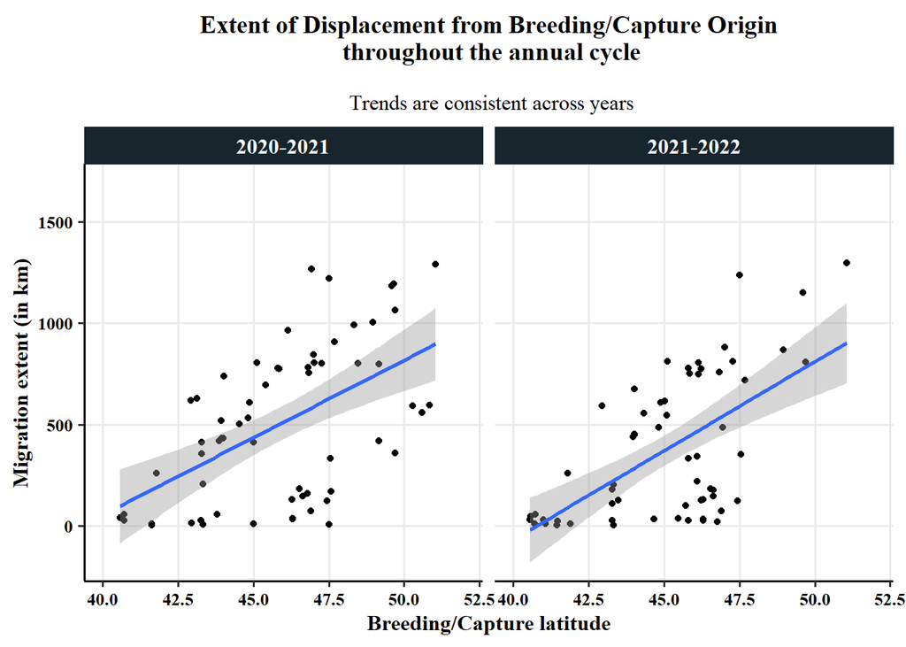

```r
p_dates %>%
  filter(id_year!="9N-2021-2022" & id_year!="6M-2021-2022") %>%
  filter(entire_yr!="2019-2020") %>%
  ggplot(., aes(breeding_lat, mig_extent))+
  geom_point()+
  geom_smooth(method="lm")+
  xlim(40,52)+ # to exclude arkansas winter captures
  facet_wrap(~entire_yr)+
  ggtitle(label="Extent of Displacement from Breeding/Capture Origin\n throughout the annual cycle",
          subtitle="\n Trends are consistent across years")+
  theme(plot.title = element_text(hjust=0.5, size=14),
        plot.subtitle = element_text(hjust=0.5, size=12))+
  labs(x="Breeding/Capture latitude", y="Migration extent (in km)")
```

We can impose 3 latitudinal categories of: 1) obligate long-distance migration (latitudes further north than 48)  
2) facultative migration (42.5-48)  
3) close to obligate residency:(further south than 42.5)

and also a threshold of 300km for “long-distance migration”, though this is totally arbitrary.

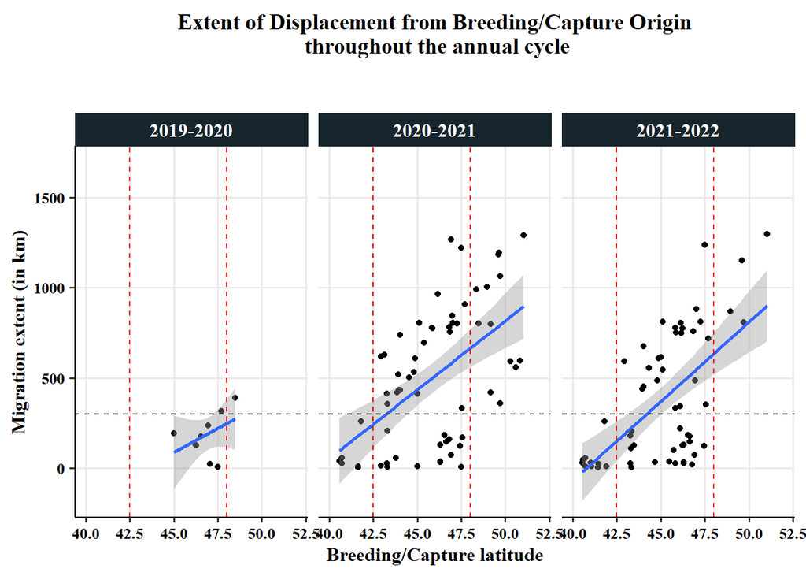

```r
p_dates %>%
  filter(id_year!="9N-2021-2022" & id_year!="6M-2021-2022") %>%
  ggplot(., aes(breeding_lat, mig_extent))+
  geom_point()+
  geom_smooth(method="lm")+
  xlim(40,52)+ # to exclude arkansas winter captures
  facet_wrap(~entire_yr)+
  ggtitle(label="Extent of Displacement from Breeding/Capture Origin\n throughout the annual cycle",
          subtitle="\n ")+
  theme(plot.title = element_text(hjust=0.5, size=14),
        plot.subtitle = element_text(hjust=0.5, size=12))+
  geom_vline(xintercept=42.5, linetype="dashed", color="red")+
  geom_vline(xintercept = 48, linetype="dashed", color="red")+
  geom_hline(yintercept=300, linetype="dashed", color="black")+
  labs(x="Breeding/Capture latitude", y="Migration extent (in km)")
```

2. How long are swans spending overwintering in non-breeding areas?

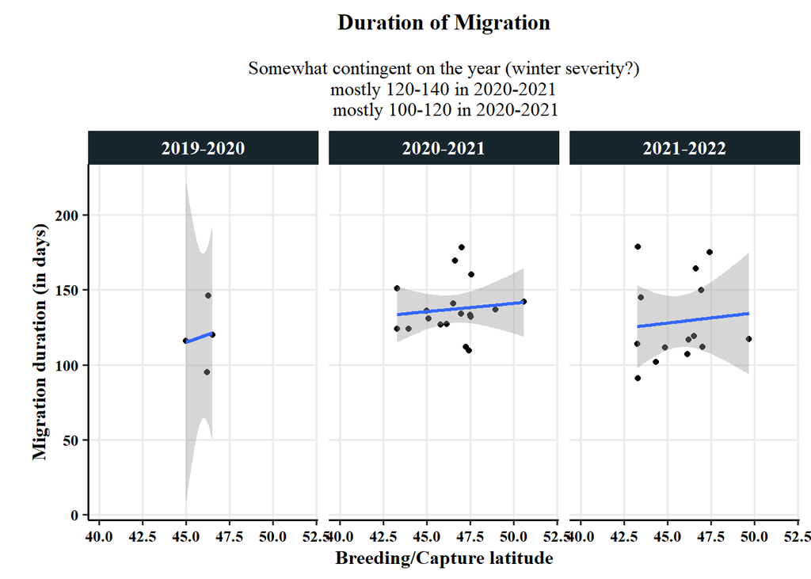

```r
p_dates %>%
  filter(id_year!="9N-2021-2022" & id_year!="6M-2021-2022") %>%
  ggplot(., aes(breeding_lat,mig_duration,))+
  geom_point()+
  geom_smooth(method="lm")+
  xlim(40,52)+ # to exclude arkansas winter captures
  facet_wrap(~entire_yr)+
  ggtitle(label="Duration of Migration",
          subtitle="\n Somewhat contingent on the year (winter severity?) \n mostly 120-140 in 2020-2021 \n mostly 100-120 in 2020-2021")+
  theme(plot.title = element_text(hjust=0.5, size=14),
        plot.subtitle = element_text(hjust=0.5, size=12))+
  labs(x="Breeding/Capture latitude", y="\nMigration duration (in days)")
```

I wonder if my rule set is too restrictive. There aren’t a ton of data points for the duration of migration because there are a bunch of reasons why swans could get excluded from fall onset or spring arrival parameters.

A special request by John: Migration duration vs extent

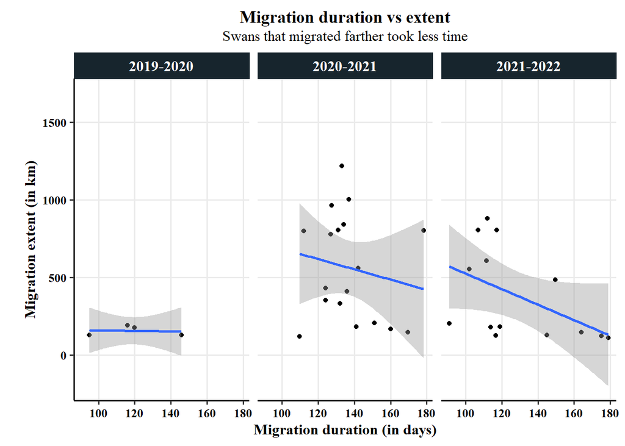

```r
p_dates %>%
  filter(id_year!="9N-2021-2022" & id_year!="6M-2021-2022") %>%
  ggplot(., aes(mig_duration,mig_extent))+
  geom_point()+
  geom_smooth(method="lm")+
  facet_wrap(~entire_yr)+
  ggtitle(label="Migration duration vs extent",
          subtitle="Swans that migrated farther took less time")+
  theme(plot.title = element_text(hjust=0.5, size=14),
        plot.subtitle = element_text(hjust=0.5, size=12))+
  labs(x="Migration duration (in days)", y="\nMigration extent (in km)")
```

3. What are the dates that swans leave their summer territory in the fall and return in the spring?

Fall onset:

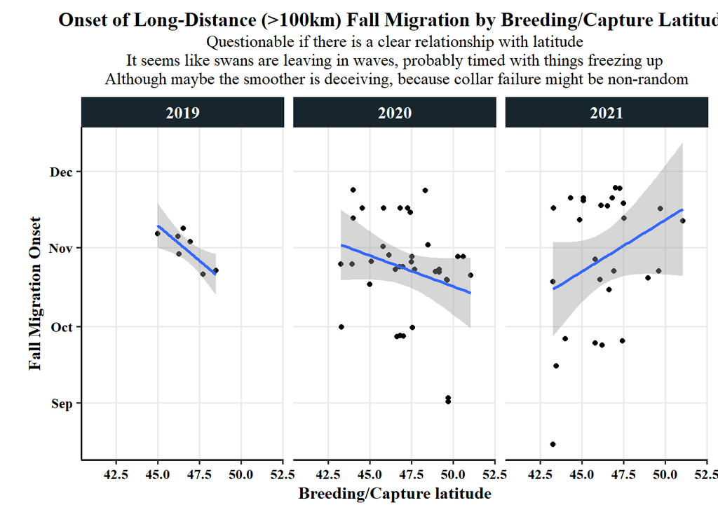

```r
p_dates %>%
  filter(!is.na(breeding_status)) %>%
  ggplot(aes( breeding_lat,fall_mig_onset))+
  geom_point()+
  geom_smooth(method="lm")+
  facet_wrap(~fall_yr)+
  xlim(41,52)+
  ggtitle(label="Onset of Long-Distance (>100km) Fall Migration by Breeding/Capture Latitude",
          subtitle="Questionable if there is a clear relationship with latitude\n It seems like swans are leaving in waves, probably timed with things freezing up \n Although maybe the smoother is deceiving, because collar failure might be non-random")+
  theme(plot.title = element_text(hjust=0.5, size=14),
        plot.subtitle = element_text(hjust=0.5, size=12))+
  labs(x="Breeding/Capture latitude", y="\nFall Migration Onset")
```

Spring arrival:

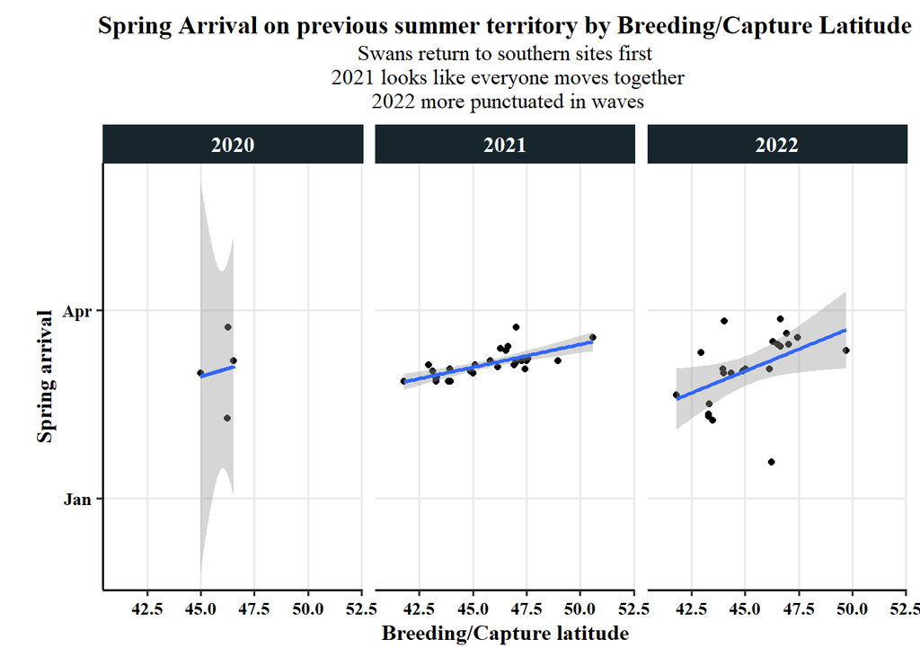

```r
p_dates %>%
  filter(!is.na(breeding_status)) %>%
  ggplot(aes( breeding_lat,spring_arrival))+
  geom_point()+
  geom_smooth(method="lm")+
  facet_wrap(~spring_yr)+
  xlim(41,52)+
  ggtitle(label="Spring Arrival on previous summer territory by Breeding/Capture Latitude",
          subtitle="Swans return to southern sites first\n 2021 looks like everyone moves together\n 2022 more punctuated in waves")+
  theme(plot.title = element_text(hjust=0.5, size=14),
        plot.subtitle = element_text(hjust=0.5, size=12))+
  labs(x="Breeding/Capture latitude", y="\nSpring arrival")
```

### Breeding status

1. How far are swans moving from summer territories during the non-breeding period?  
   Migration extent:

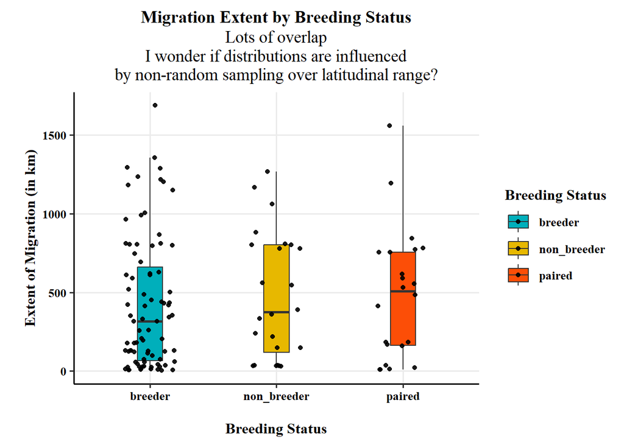

```r
p_dates %>%
  filter(breeding_status%in%c("breeder", "non_breeder", "paired")) %>%
  ggplot(., aes(breeding_status, mig_extent, fill=breeding_status))+
  geom_boxplot(width=0.2, outlier.shape = NA)+
  geom_jitter(width=0.2,alpha=0.9)+
  scale_fill_manual(values = c("#00AFBB", "#E7B800", "#FC4E07"))+
  ggtitle(label="Migration Extent by Breeding Status",
          subtitle="Lots of overlap\n I wonder if distributions are influenced \nby non-random sampling over latitudinal range?")+
  theme(plot.title = element_text(hjust=0.5, size=14),
        plot.subtitle = element_text(hjust=0.5, size=14))+
  labs(x="\nBreeding Status", y="\nExtent of Migration (in km)", fill="Breeding Status")
```

2. How long are swans spending overwintering in non-breeding areas?

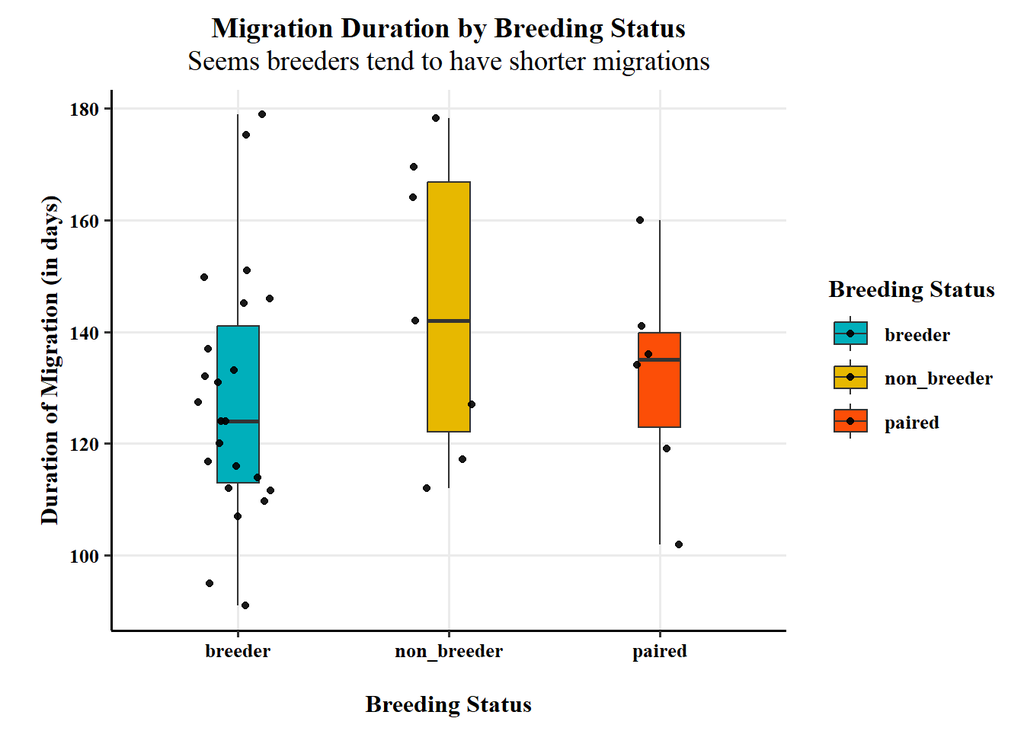

```r
p_dates %>%
  filter(breeding_status%in%c("breeder", "non_breeder", "paired")) %>%
  ggplot(., aes(breeding_status, mig_duration, fill=breeding_status))+
  geom_boxplot(width=0.2, outlier.shape = NA)+
  geom_jitter(width=0.2,alpha=0.9)+
  scale_fill_manual(values = c("#00AFBB", "#E7B800", "#FC4E07"))+
  ggtitle(label="Migration Duration by Breeding Status",
          subtitle="Seems breeders tend to have shorter migrations")+
  theme(plot.title = element_text(hjust=0.5, size=14),
        plot.subtitle = element_text(hjust=0.5, size=14))+
  labs(x="\nBreeding Status", y="\nDuration of Migration (in days)", fill="Breeding Status")
```

3. What are the dates that swans leave their summer territory in the fall and return in the spring?

Fall onset:

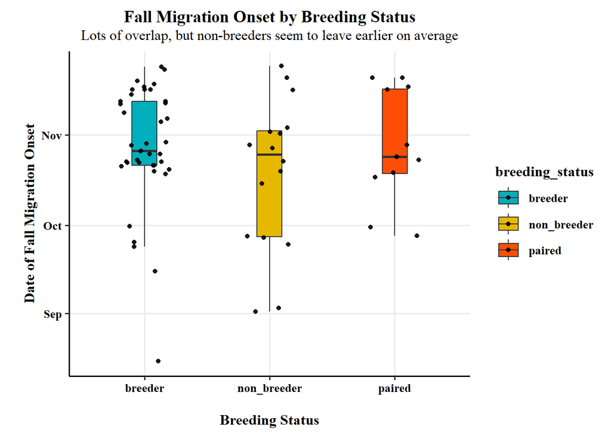

```r
p_dates %>%
  filter(breeding_status%in%c("breeder", "non_breeder", "paired")) %>%
  ggplot(., aes(breeding_status, fall_mig_onset, fill=breeding_status))+
  geom_boxplot(width=0.2, outlier.shape = NA)+
  geom_jitter(width=0.2,alpha=0.9)+
  scale_fill_manual(values = c("#00AFBB", "#E7B800", "#FC4E07"))+
  ggtitle(label="Fall Migration Onset by Breeding Status",
          subtitle="Lots of overlap, but non-breeders seem to leave earlier on average")+
  theme(plot.title = element_text(hjust=0.5, size=14),
        plot.subtitle = element_text(hjust=0.5, size=12))+
  labs(x="\nBreeding Status", y="\nDate of Fall Migration Onset")
```

Spring arrival:

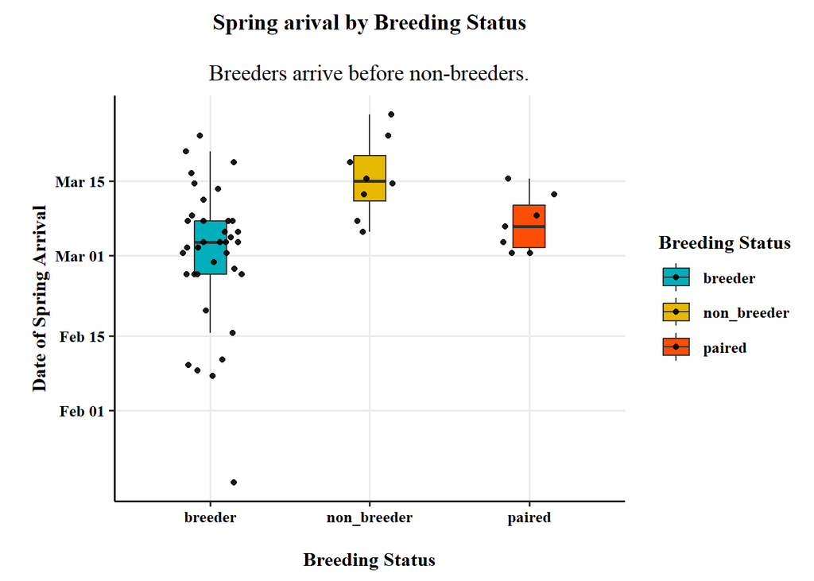

```r
p_dates %>%
  filter(breeding_status%in%c("breeder", "non_breeder", "paired")) %>%
  ggplot(., aes(breeding_status, spring_arrival, fill=breeding_status))+
  geom_boxplot(width=0.2, outlier.shape = NA)+
  geom_jitter(width=0.2,alpha=0.9)+
  scale_fill_manual(values = c("#00AFBB", "#E7B800", "#FC4E07"))+
  ggtitle(label="Spring arival by Breeding Status",
          subtitle="\nBreeders arrive before non-breeders.")+
  theme(plot.title = element_text(hjust=0.5, size=14),
        plot.subtitle = element_text(hjust=0.5, size=14))+
  labs(x="\nBreeding Status", y="\nDate of Spring Arrival", fill="Breeding Status")
```

Spring onset (departure from furthest extent segment)

[figure not shown]

```r
p_dates %>%
  filter(breeding_status%in%c("breeder", "non_breeder", "paired")&
           furthest_seg_departure < '2020-05-01') %>%
  ggplot(., aes(breeding_status, furthest_seg_departure, fill=breeding_status))+
  geom_boxplot(width=0.2, outlier.shape = NA)+
  geom_jitter(width=0.2,alpha=0.9)+
  scale_fill_manual(values = c("#00AFBB", "#E7B800", "#FC4E07"))+
  ggtitle(label="Spring Migration Onset by Breeding Status",
          subtitle="Lots of overlap, but non-breeders seem to leave earlier on average")+
  theme(plot.title = element_text(hjust=0.5, size=14),
        plot.subtitle = element_text(hjust=0.5, size=12))+
  labs(x="\nBreeding Status", y="\nDate of Spring Migration Onset")
```

[output not shown]

Could look at legnth of fall migration (arrival-onset) and length of spring migration (arrival-onset) for lat and breeding class.

Also, consider adding in plots that account for both timing and extent with either lat or breeding class (or both)

Plot showing the timing of migration with beginning lat and ending lat on the y axis and time on the x (or flipped). would look like spaghetti plots

Assuming there are 2 different movement strategies going on, are they happening in parallel (i.e. same time) or at different times?

[figure not shown]

```r
p_dates %>%
  filter(id_year!="9N-2021-2022" & id_year!="6M-2021-2022") %>%
  ggplot(., aes(fall_mig_onset,mig_extent))+
  geom_point()+
  geom_smooth(method="lm")+
  facet_wrap(~entire_yr)+
  ggtitle(label="Fall onset vs extent",
          subtitle="Swans that left later traveled further")+
  theme(plot.title = element_text(hjust=0.5, size=14),
        plot.subtitle = element_text(hjust=0.5, size=12))+
  labs(x="Fall Onset of migration", y="\nMigration extent (in km)")
```